This project focused on analyzing a dataset from Kraggle that contained data relevant to the Used Cars Market in Belarus. Using this dataset we utilized visualization and machine learning methods to gain insight into what this data meant. We ultimately wanted to know what the lead indicator was for how much a car would sell for in Belarus (manufacturer, location, etc.).Therefore through gathering insights on data we could gauge how much the selling price of a car would be in Belarus.

# Analysis of Used Car Prices in Belarus

Brandon Strong, Emma Doyle, Matthew Lane, Mikhail Mikhaylov, Reid Hoffmeier

4/14/2021

## Project Goal

Our main goal was to use the Belarus Dataset we retrieved to study which features of a car would have the largest impact on the appeal vehicles may have to a buyer. This mainly consists of taking each feature of the dataset and comparing it to the price listed, and seeing if there was any trend, and if so was that trend upwards or downwards which would indicate that feature being something a buyer focuses on when buying. The larger a trend's slope the more of an impact a certain feature would have on the sellability of a particular vehicle to the consumer base in Belarus.

The particular questions we focused on in the analysis of the data are as follows:  
- What impact does a region have on price? Box Plot, One-Way Anova  
- What is the distribution of manufacturers and whether manufacturers have a significant impact on the asking price of a vehicle? Pie Graph/Box Plot, One-Way Anova/ Kruskal-Wallis rank sum test  
- What is the relationship between odometer and price? Scatter Plot/Box-Plot, Simple Regression Analysis  
- Does the number of photos a vehicle has impact the selling price? Scatter Plot, Simple Regression Analysis  
- Does the number of times a vehicle has been upped in the catalog to raise its position impact the selling price? Scatter Plot, Simple Regression Analysis  
- Relationship between Engine Type and Body Type? What is the impact of Engine Type and Body Type on the selling price? Mosaic Plot/ Chi-Squared Test, Two-Way ANOVA /Kruskal-Wallis rank sum test  
- What is the most popular model and whether we can conclude that the popularity of a model has a direct impact on the price of a vehicle? Dplyr count with group_by to find the most popular model by region. One-Way ANOVA Test/ Kruskal-Wallis rank sum test  
- What is the average age of each vehicle manufacturer and whether the manufacturer changes how the production year impacts the selling price? Bar graph, Two-Way ANOVA/ Kruskal-Wallis rank sum test

## Dataset Used

The dataset used in this project was "Used Cars Market in Belarus" from the website Kaggle. All of the data within the dataset was collected December 2, 2019 from a popular Belarus catalog containing used car advertisements. The dataset had 30 different attributes per vehicle and a total of 38531 samples of data. The attributes of each listing in the dataset are as follows:  
-Manufacturer Name  
-Model Name  
-Transmission Type  
-Color  
-Odometer Value  
-Year Produced  
-Engine Fuel  
-Engine Has Gas  
-Engine Type  
-Engine Capacity  
-Body Type  
-Has Warranty  
-(State)Condition of the Vehicle  
-Drivetrain Type  
-Price in USD  
-Exchangeability  
-Location Region  
-Number of Photos  
-Number of Up Counts  
-Features {0,1,2,3,4,5,6,7,8,9}  
-Duration Listed

## Preparing the data

We first read our dataset into the cars variable

```r
cars <- read_csv("cars.csv")
```

Lets prepare the dataset for evaluation

```r
cars_edited <- select(cars, -8 & -(12:13) & -(20:29))
View(cars_edited) #view the data
```

```r
#Check if there are na's in the cars_edited
colSums(is.na(cars_edited))
```

```
## manufacturer_name        model_name      transmission             color
##                 0                 0                 0                 0
##    odometer_value     year_produced       engine_fuel       engine_type
##                 0                 0                 0                 0
##   engine_capacity         body_type        drivetrain         price_usd
##                10                 0                 0                 0
##   is_exchangeable   location_region  number_of_photos        up_counter
##                 0                 0                 0                 0
##   duration_listed
##                 0
```

```r
# Check for Duplicates and remove them
cars_edited <- cars_edited %>% distinct()
```

Recode foreign language into their English meaning (location_region) Recode foreign language into their English meaning (manufacturer_name) Recode foreign language into their English meaning (model_name) Recode foreign language into their English meaning (engine_fuel)

```r
cars_edited <-
  cars_edited %>%  dplyr::mutate(
    location_region =  dplyr::recode(
      cars_edited$location_region,
      'Брестская обл.' = "Brest Region",
      'Витебская обл.' = "Vitebsk Region",
      'Гомельская обл.' = "Gomel Region",
      'Гродненская обл.' = "Grodno Region",
      'Минская обл.'  = "Minsk Region",
      'Могилевская обл.' = "Mogilev Region"
    )
  )

cars_edited <-
  cars_edited %>%  dplyr::mutate(
    manufacturer_name =  dplyr::recode(
      cars_edited$manufacturer_name,
      'ВАЗ' = "AvtoVAZ",
      'ГАЗ' = "GAZ",
      'ЗАЗ' = "ZAZ",
      'Москвич' = "Moskvitch",
      'УАЗ'  = "UAZ"
    )
  )

cars_edited <-
  cars_edited %>%  dplyr::mutate(
    model_name =  dplyr::recode(
      cars_edited$model_name,
      'Таврия' = "Tavria",
      '968м' = "968M",
      'Соболь' = "Sobol",
      'Луидор' = "Luidor",
      'ВИС'  = "VIS"
    )
  )

cars_edited <-
  cars_edited %>%  dplyr::mutate(engine_fuel =  dplyr::recode(cars_edited$engine_fuel, 'gas' = "compressed natural gas", ))
```

```r
View(cars_edited)
```

## Questions

(Emma Doyle) 1) Box Plots, Bar Graph, ANOVA?: What impact does a region have on price?

[figure not shown]

(Emma Doyle) 2) Pie Graph/Box Plot, One-Way Anova?: What is the distribution of manufacturers and whether manufacturers have a significant impact on the asking price of a vehicle?

[figure not shown]

(Reid Hoffmeier) 3) Scatter Plot/Box-Plot, Simple Regression Analysis: What is the relationship between odometer and price?

[figure not shown]

(Reid Hoffmeier) 4) Scatter Plot, Simple Regression Analysis: Does the number of photos a vehicle has impact the selling price?

[figure not shown]

Finding out model popularity

```r
models_sorted <- cars_edited %>% count(model_name) %>% arrange(desc(n)) # Most popular is Passat
View(models_sorted)
```

model_price <- lm(log(price_usd) ~ model_name + year_produced, data = cars_edited)

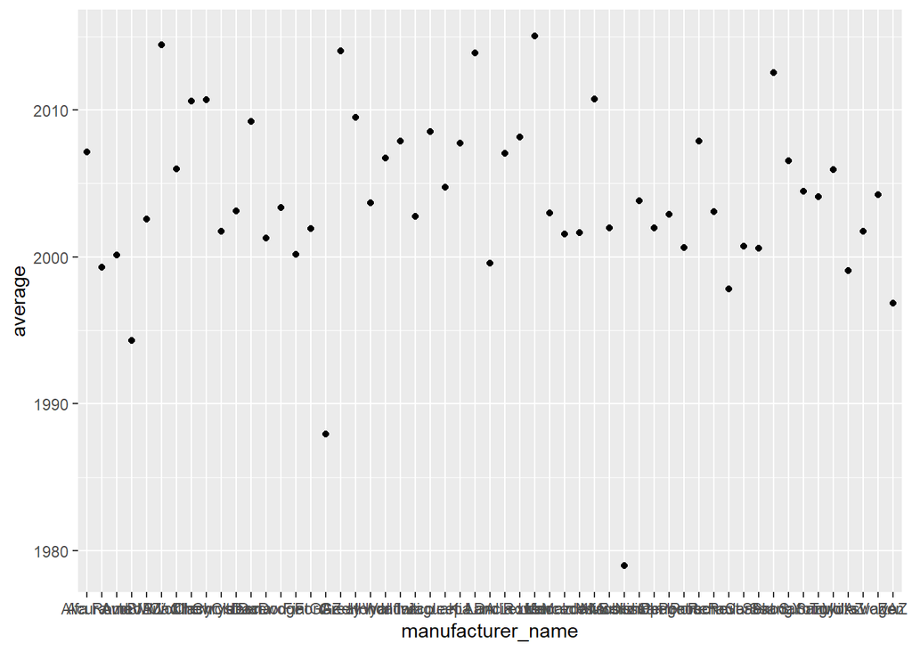

```r
manufacturer_year <- group_by(cars_edited, manufacturer_name)
manufacturer_year_averages <- summarise(manufacturer_year, average = mean(year_produced, na.rm = TRUE))
View(manufacturer_year_averages)

ggplot(manufacturer_year_averages) + geom_point(aes(x = manufacturer_name, y = average))
```

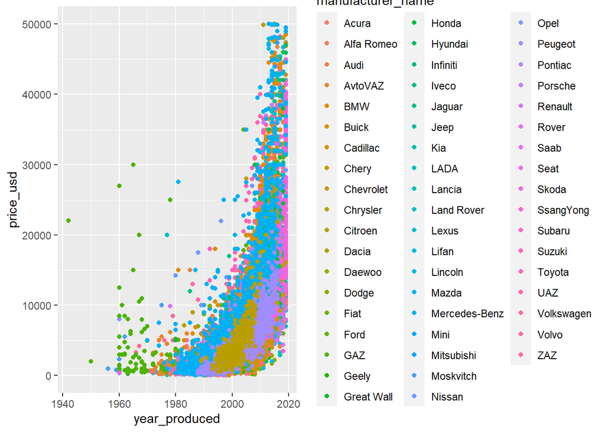

```r
ggplot(cars_edited) + geom_point(aes(x = year_produced, y = price_usd, color = manufacturer_name))
```